# Dokumentation

Mit Hilfe dieses Bausteines ist es möglich, per Binäreingänge oder ähnliche “zustandslose” Sender, einen Aktor umzuschalten oder zu dimmen. Beispiele hierfür ist das An-/Ausschalten und Dimmen eines Lichts per Taste an einem RF Tastsensor. Der RF Tastsensor kennt den Zustand des Lichts nicht und kann deshalb nicht entscheiden, ob er bei einer Betätigung an- oder ausschalten soll, weshalb klassischer Weise in diesem Falle jeweils eine Taste für Ein- und Ausschalten verwendet wird.

Der Baustein “Umschalten und Dimmen per Binäreingang” kennt den Zustand des Aktors und hat deshalb alle Möglichkeiten, die ein drahtgebundener Tastsensor auch hat.

Es gibt drei Modi, in denen dieser Baustein genutzt werden kann, die weiter unten näher beschrieben werden:

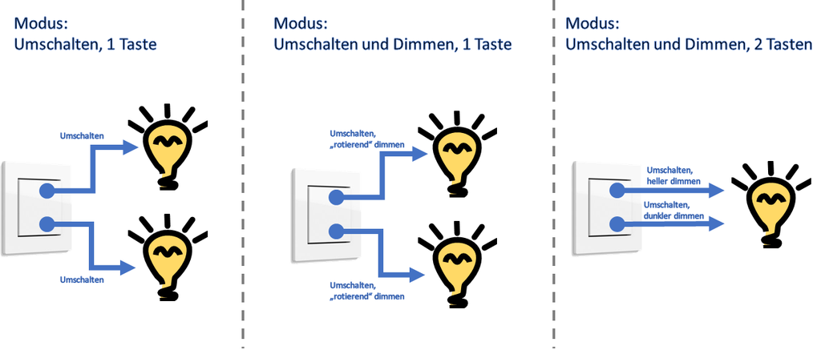

## Modus “Umschalten, 1 Taste”

Dieser Modus kann mit allen Aktoren verwendet werden, die ein 1-bit Schaltobjekt und 1-bit Rückmeldeobjekt anbieten. Diese müssen im GPA als ein Datenpunkt zusammengefasst werden. Wenn in diesem Modus mehrere Geräte mit unterschiedlichen Wippen auf demselben Schalter umgeschaltet werden sollen, ist für jede Wippe ein weiterer Logikbaustein zu verwenden.

### Eingänge

| Bezeichnung | Porttyp | Beschreibung |
| --- | --- | --- |
| `Umschalten` | BOOL | Empfängt das Umschaltsignal vom Taster oder Binäreingang. Es wird lediglich auf gesendete “1”-Telegramme reagiert, etwaige “0”-Telegramme werden ignoriert. |
| `Aktueller Schaltzustand` | BOOL | Empfängt den aktuellen Schaltzustand des Aktors. Dieser Eingang sollte unbedingt mit demselben Datenpunkt wie der Ausgang “Schalten” verbunden werden. |

### Ausgänge

[output not shown]

## Modus “Umschalten und Dimmen, 1 Taste”

Dieser Modus funktioniert prinzipiell wie Modus “Umschalten, 1 Taste”, jedoch kann zusätzlich per Halten der Wippe gedimmt werden. Dabei wird “rotierend” gedimmt. D.h. bei jedem Mal wird zwischen heller Dimmen und dunkler Dimmen gewechselt. Um diesen Modus zu benutzen, wird neben den 1-bit Schalt- und Rückmeldeobjekten auch ein relatives Dimmobjekt vom Typ 3.007 “Dimmer Schritt” (oder kompatibel) am Aktor benötigt.

### Parameter

| Bezeichnung | Porttyp | Einheit | Beschreibung |
| --- | --- | --- | --- |
| `Zeit zwischen Schalten und Dimmen` | INTEGER | Millisekunden | Gibt an, wie lange eine Taste gedrückt gehalten werden muss, damit das Dimmen beginnt |
| `Dimmen um...` | INTEGER | Prozent | Gibt an, um wie viel Prozent gedimmt werden soll. Dieser Parameter muss passend zur Konfiguration des KNX Kommunikationsobjekts des relativen Dimmens des Aktors eingestellt werden. |

### Eingänge

[output not shown]

### Ausgänge

[output not shown]

## Modus “Umschalten und Dimmen, 2 Tasten”

Dieser Modus entspricht dem üblichen Verhalten eines Tastsensors im Modus “Dimmen”, kann jedoch auch mit nicht-dimmfähigen Eingabegeräten benutzt werden. Das sind beispielsweise KNX Binäreingänge, die keinen Dimmmodus unterstützen, oder systemfremde Sensoren, die über ein Gateway eingebunden werden. Wie beim Modus “Umschalten und Dimmen, 1 Taste” wird ein Aktor mit 1-bit Schalt- und Rückmeldeobjekten und relativem Dimmobjekt vom Typ 3.007 “Dimmer Schritt” (oder kompatibel) benötigt.

### Parameter

| Bezeichnung | Porttyp | Einheit | Beschreibung |
| --- | --- | --- | --- |
| `Zeit zwischen Schalten und Dimmen` | INTEGER | Millisekunden | Gibt an, wie lange eine Taste gedrückt gehalten werden muss, damit das Dimmen beginnt |
| `Dimmen um...` | INTEGER | Prozent | Gibt an, um wie viel Prozent gedimmt werden soll. Dieser Parameter muss passend zur Konfiguration des KNX Kommunikationsobjekts des relativen Dimmens des Aktors eingestellt werden. |

### Eingänge

[output not shown]

### Ausgänge

[output not shown]

# Hilfestellung

Hilfe bei Fragen zu diesem Baustein erhalten Sie am besten über das KNX-User-Forum im Bereich [Gira Logik SDK](https://knx-user-forum.de/forum/supportforen/gira-logik-sdk). Ein Account im KNX-User-Forum kann kostenfrei erstellt werden.

Erwähnen Sie @dalbuschat in Ihrem Posting, damit der Autor per E-Mail über Ihr Anliegen benachrichtigt wird. Da es sich um einen kostenfreien Baustein handelt, kann leider keine Gewährleistung gegeben werden, noch kann Support zugesagt werden.

# Nutzungslizenz

Dieser Baustein unterliegt der MIT License:

```
MIT License

Copyright (c) 2018-2019 Albuschat, Daniel

Permission is hereby granted, free of charge, to any person obtaining a copy
of this software and associated documentation files (the "Software"), to deal
in the Software without restriction, including without limitation the rights
to use, copy, modify, merge, publish, distribute, sublicense, and/or sell
copies of the Software, and to permit persons to whom the Software is
furnished to do so, subject to the following conditions:

The above copyright notice and this permission notice shall be included in all
copies or substantial portions of the Software.

THE SOFTWARE IS PROVIDED "AS IS", WITHOUT WARRANTY OF ANY KIND, EXPRESS OR
IMPLIED, INCLUDING BUT NOT LIMITED TO THE WARRANTIES OF MERCHANTABILITY,
FITNESS FOR A PARTICULAR PURPOSE AND NONINFRINGEMENT. IN NO EVENT SHALL THE
AUTHORS OR COPYRIGHT HOLDERS BE LIABLE FOR ANY CLAIM, DAMAGES OR OTHER
LIABILITY, WHETHER IN AN ACTION OF CONTRACT, TORT OR OTHERWISE, ARISING FROM,
OUT OF OR IN CONNECTION WITH THE SOFTWARE OR THE USE OR OTHER DEALINGS IN THE
SOFTWARE.
```